# Veg descriptive statistics by site & treatment type

Kathleen Stutzman

2024-02-20

This script creates an average for each site and then calculates species richness, species diversity (Shannon Index), species numbers, evenness, and beta diversity for veg data.

Libraries:

```r
# libraries -------------------
library(vegan)
library(tidyverse)
library(plyr)
library(dplyr)
library(adespatial)
```

Set working directory

```r
knitr::opts_knit$set(root.dir = '/Users/user/Desktop/Data/Regen_RProj/')
```

Source functions:

```r
# source functions -------------------
source("Functions/species_richness.R")
source("Functions/shannon_index.R")
source("Functions/spec_num.R")
source("Functions/Pielous_J.R")
source("Functions/asnum_keepname.R")
```

Source veg data:

```r
#start by sourcing the veg script
source("Scripts/Veg_Data.R")

rm(veg3)#this is used for total cover in GLMMs; not used in this script and doesn't import correctly due to use of dplyr package
```

Split overall data from veg cover; pivot wider to fill in missing 0s; create df of site and plot to reattach later

```r
#split overall data from veg cover
veg_meta <- veg2 %>%
  select(Region, Treat_Type, Site, Plot_No) %>%
  distinct(Plot_No, .keep_all = TRUE)

#pivot veg data wider and fill in zeros
veg_wider <- veg2 %>%
  select(Plot_No, Species_Code, SP_Cover_midpoint) %>%
  group_by(Plot_No) %>%
  pivot_wider(names_from = Species_Code, values_from = SP_Cover_midpoint, values_fill = 0)

#create dataframe of site and plot
veg_site <- veg2 %>%
  select(Site, Plot_No) %>%
  group_by(Site) %>%
  distinct(Plot_No, .keep_all = TRUE)

#reattach site info and reorder
veg_merge1 <- merge(veg_site, veg_wider, by = "Plot_No") %>%
   select(Site, Plot_No, everything())

rm(veg_wider)
```

Create df without plot numbers; then split df by site

```r
#remove plot number
veg_merge3 <- veg_merge1 %>%
  select(-Plot_No)

#split df by site
split_veg <- split(veg_merge3[-1], veg_merge3$Site)
```

##### Species Richness

```r
# Species Richness (jackknife and chao etc estimates) -------------------
sp <- as.data.frame(sapply(split_veg, species_richness))

#transpose
spcrich_bysite <- as.data.frame(t(sp))

rm(sp)
```

##### Diversity (Shannon-Wiener Index)

```r
# Shannon index -------------------
si <- as.data.frame(sapply(split_veg, shannon_index))

#transpose
si_bysite <- as.data.frame(t(si))

#name columns
colnames(si_bysite) <- c("S.I._Mean", "S.I._SD")

rm(si)
```

##### Species Number

```r
# Number of species -------------------
spc_n <- as.data.frame(sapply(split_veg, spec_num))

#transpose
spcnum_bysite <- as.data.frame(t(spc_n))

#name columns
colnames(spcnum_bysite) <- c("Spc.Num_Mean", "Spc.Num_SD")

rm(spc_n)
```

##### Evenness (Pielou’s J)

This is the SW Index / log (species number). For three sites (one each in APB_Hippo, RPD2_B2, & RPD2_B7), they have a species number of 1. The log of 1 is 0 and anything divided by 0 is NaN. Therefore, these three subplots are dropped from the calculations

```r
even1 <- as.data.frame(sapply(split_veg, Pielous_J))

even2 <- as.data.frame(t(even1))

colnames(even2) <- c("Pielous_J_mean", "Pielous_J_SD")

rm(even1)
```

Hidden below is code to look at the three subplots, if desired

### Sorensen dissimilarity index

```r
# creating a dataframe where observations from every subplot within a site are added together to use for P/A calculations in sorensen
veg4soren <- veg_merge3 %>%
  group_by(Site) %>%
  summarise_at(vars(QUCO:HECA), sum) %>%
  column_to_rownames(var = "Site")

# creating df of row id and site id to reattach to beta diversity metrics later
site_rowid <- veg_merge3 %>%
  group_by(Site) %>%
  summarise_at(vars(QUCO:HECA), sum) %>%
  rowid_to_column(var="rowid") %>%
  select(Site, rowid)
```

Calculate beta diversity

```r
BDiv <- beta.div.comp(veg4soren, coef = "S", quant = FALSE)
#overall values
BetaD.df <- as.data.frame(BDiv$part)
#distance matrix for all sites
BetaD.distances <- as.matrix(BDiv$D)
#replacement values matrix for all sites
BetaD.repl.matrix <- as.matrix(BDiv$repl)
#richness values matrix for all sites
BetaD.rich.matrix <- as.matrix(BDiv$rich)
```

#### Overall beta diversity metrics

```r
print(BetaD.df)
```

```
##                 BDiv$part
## BDtotal         0.3054104
## Repl            0.1795761
## RichDif         0.1258343
## Repl/BDtotal    0.5879828
## RichDif/BDtotal 0.4120172
```

#### Distance matrix for all sites

```r
#print(BetaD.distances)
```

Local contributions to beta diversity; partitioned into richness and replacement

```r
# replacement
replacement <- LCBD.comp(BDiv$repl, sqrt.D = TRUE)

rep.df <- as.data.frame(replacement$LCBD)

names(rep.df)[names(rep.df) == "replacement$LCBD"] <- "replace.lcbd"

rep.df <-  rep.df %>%
  rowid_to_column(var="rowid")

rep.df2 <- merge(rep.df, site_rowid, by = "rowid") %>%
  select(Site, replace.lcbd) %>%
  column_to_rownames(var = "Site")


#richness
richness <- LCBD.comp(BDiv$rich, sqrt.D = TRUE)

rich.df <- as.data.frame(richness$LCBD)

names(rich.df)[names(rich.df) == "richness$LCBD"] <- "richness.lcbd"

rich.df <- rich.df %>%
  rowid_to_column(var = "rowid")

rich.df2 <- merge(rich.df, site_rowid, by = "rowid") %>%
  select(Site, richness.lcbd) %>%
  column_to_rownames(var = "Site")

rm(rep.df, rich.df)
```

### Merge DS together

```r
# merging data sets of DS
m1 <- merge(spcrich_bysite, si_bysite, by="row.names") %>%
  column_to_rownames(var = "Row.names")


m2 <- merge(m1, spcnum_bysite, by="row.names") %>%
  column_to_rownames(var = "Row.names")

m3 <- merge(m2, even2, by = "row.names") %>%
  column_to_rownames(var = "Row.names")


m4 <- merge(m3, rich.df2, by = "row.names") %>%
  column_to_rownames(var = "Row.names")

veg_sd <- merge(m4, rep.df2, by = "row.names") %>%
  column_to_rownames(var = "Row.names")


rm(m1,
   m2,
   m3,
   m4)
```

```r
print(veg_sd)
```

```
##               Species     chao   chao.se    jack1  jack1.se    jack2     boot
## APB_Alleycat       34   54.625   14.8034    47.75   5.04356 56.46212 39.94441
## APB_Bivy           37 61.54545   16.0886 53.36364  5.905593 63.67273 44.06097
## APB_Chubb_E        32 42.90909  8.391259 42.90909  4.359847 48.30909 36.91184
## APB_Chubb_W        19 37.33333  15.89316       29  4.670994 35.79091 23.19411
## APB_Dandy          36 53.96667  13.21952 48.83333  4.574992 56.71212 41.65737
## APB_Fowlers        37       81  27.98571       57  6.875517 71.31818 45.35005
## APB_Hippo          30    36.05  4.840139     39.9  4.828043     42.3 34.89372
## APB_Hoffman        35 53.76623  12.32641 50.45455  5.514819 59.20909  41.7736
## APB_HuckMound      24 100.8182  88.28111 35.81818   5.20648 45.71818 28.72131
## APB_Humdinger      27 32.72917  4.791808 36.16667  3.728643 38.43939 31.44973
## APB_Hydro          25     28.6  3.420526     32.2  3.174902 32.91111 28.74547
## CE_B7_B            16 21.72917  6.956977 20.58333  2.049729 23.23485 18.02833
## CE_B7_C            17    20.75   4.43706     21.5  2.012461 23.36667 19.13508
## CE_B7_D            19 28.77778  9.457725 26.33333  3.496029 30.72727 22.18417
## CE_BA3             24   51.225  25.83317     33.9  4.013726 41.27778 28.17638
## CE_BP20            16 29.63636  12.43387 21.45455   2.93173 26.36364 18.17316
## CE_SWB_E1          22    40.15     15.74     31.9  5.010988 38.56667 26.19814
## CE_SWB_N           21   25.125   4.44102     26.5  3.246793  28.4697 23.64098
## CE_SWB_S           15 22.27273  10.63287 18.63636  2.263618 21.17273 16.57347
## CE_Wheelock        19 23.09091  4.408154 24.45455   2.93173 26.41818 21.66463
## Mashpee_B1         21 36.15152  13.54628 30.09091  5.142595 36.06364 24.90915
## Mashpee_C           9 16.11111  10.40418 12.55556  1.777778 14.98611 10.48992
## Mashpee_G3          7 7.227273 0.6780197 7.909091 0.9090909 7.254545 7.570486
## MS_07a             15 18.66667   4.88194 18.66667  1.833333 20.48485 16.70515
## MS_09d             12 23.45833  15.74123 16.58333  2.456567 19.99242 13.87987
## RPD2_B1            14       30  21.03965 19.33333  3.925227 23.31944 16.27092
## RPD2_B2            13 20.11111  10.40418 16.55556  2.222222 18.98611 14.52742
## RPD2_B3            11 14.55556  4.745368 14.55556  1.777778 16.30556 12.62144
## RPD2_B4             9 9.444444  1.196703 9.888889 0.8888889 9.986111 9.555325
## RPD2_B5             8      8.8  1.549193      9.6  1.697056      9.9  8.83168
## RPD2_B6            16 16.35556 0.7960396 17.77778  1.257079 15.93056  17.3032
## RPD2_B7             7 9.666667  3.978229 9.666667  1.539601       12 8.045038
## RPD2_B8             9 14.33333  6.365641 12.55556  2.222222 15.66667 10.43778
## RPD2_B9             6      7.6  3.046309      7.6  1.131371     8.35  6.74368
## SPNHF_Harmon       14  16.0625  3.140275    16.75  1.587713 17.73485 15.35316
## TNCO_B1            12 13.84615  3.474335 13.84615  1.305428 14.76282 12.88685
## TNCO_ESDB1         15 23.18182  9.288756 20.45455   2.93173 23.89091 17.32311
## TNCO_ESDB2         13 35.45833  28.54909 19.41667  3.635282 24.49242 15.57616
## TNCO_Hobbs5        16 21.68182  6.902883 20.54545  2.439347 23.16364 18.04654
```

[output cut: 89 more lines]

```
## RPD2_B8            0.8038368   0.10533084   0.032756902  0.017157176
## RPD2_B9            0.7667932   0.03390891   0.057684154  0.003290114
## SPNHF_Harmon       0.7683407   0.09720833   0.012224642  0.021008534
## TNCO_B1            0.8115927   0.13044652   0.018182805  0.019972785
## TNCO_ESDB1         0.7678689   0.07638842   0.010209192  0.026571022
## TNCO_ESDB2         0.7829126   0.12836588   0.014854082  0.020044859
## TNCO_Hobbs5        0.7752957   0.08820551   0.009685288  0.021192080
## TNCO_WB1           0.6152284   0.16807687   0.010209192  0.023528255
## TNCO_WB10          0.7815753   0.09075137   0.010209192  0.026667395
## TNCO_Zito2         0.7423692   0.13864355   0.018915470  0.024830497
## TNCW_10SE          0.7072149   0.12984160   0.010209192  0.029739429
## TNCW_12            0.7623330   0.13417311   0.017127891  0.024034709
## TNCW_14            0.6390657   0.21614942   0.022314502  0.028654217
## TNCW_18            0.6617116   0.17340440   0.015703915  0.022176477
## TNCW_7SW           0.7016679   0.11415434   0.010936607  0.021115719
```

# Averages by treatment type:

Using information calculated by site to create an average value for each treatment type

```r
#species richness data is numbers but not numeric, so convert to numeric so I can find the mean
veg_sd2 <- as.data.frame(asnum_keepname(veg_sd))

#checking
is.numeric(veg_sd2$chao)
```

```
## [1] TRUE
```

```r
#pull out site and treatment type data, so it can be connected with DS data
trt_meta <- veg_meta %>%
  select(Site, Treat_Type) %>%
  distinct(Site, .keep_all = T) %>%
  column_to_rownames(var = "Site")

#merge and make df ready to split
veg_trt <- merge(veg_sd2, trt_meta, by = "row.names")  %>%
  select(Treat_Type, everything()) %>%
  select(-Row.names)

#split dataframe by treat type
treat_split <- split(veg_trt[-1], veg_trt$Treat_Type)


#find means for each category by treatment type
z <- as.data.frame(sapply(treat_split, colwise(mean)))

#transpose
DS_byTT <- as.data.frame(t(z))

#the applys? turn the data to not numeric? not sure exactly. This converts the dataframe to numeric
DS_byTT2 <- as.data.frame(asnum_keepname(DS_byTT))
```

#### Print Treatment Type DS

```r
print(DS_byTT2)
```

```
##           Species     chao   chao.se    jack1 jack1.se    jack2     boot
## Control  16.72727 25.26697  9.197177 22.41107 2.910847 25.33444 19.29166
## FallRx   17.00000 29.85718 14.787903 22.15631 2.880715 24.91506 19.34355
## Harvest  11.66667 16.18502  5.361206 14.64377 1.835839 16.22643 13.03912
## MowRx    24.00000 38.62945 13.435117 33.11540 3.942209 38.54840 27.98926
## SpringRx 20.44444 41.75321 20.842223 28.97475 3.862330 34.40839 24.12478
##           boot.se         n S.I._Mean   S.I._SD Spc.Num_Mean Spc.Num_SD
## Control  1.680008 10.636364  1.203229 0.3726515     5.697383   1.800755
## FallRx   1.672775 11.333333  1.344766 0.3091786     6.275499   1.883640
## Harvest  1.090081  9.333333  1.114616 0.3497960     4.795960   1.485310
## MowRx    2.059717 11.333333  1.383972 0.3767572     7.323232   1.964687
## SpringRx 1.983378  9.666667  1.314602 0.3281250     6.249046   1.645218
##          Pielous_J_mean Pielous_J_SD richness.lcbd replace.lcbd
## Control       0.7329871    0.1455960    0.02245772   0.02401150
## FallRx        0.7489876    0.1179252    0.01219184   0.02219380
## Harvest       0.7472599    0.1542950    0.02895786   0.01471323
## MowRx         0.7123887    0.1609741    0.02127836   0.02163559
## SpringRx      0.7392147    0.1375988    0.02379456   0.02091365
```

```r
library(writexl)

write_xlsx(DS_byTT2, "DataObjects/dsbyTT.xlsx")
```

Would it be different to do by tt to begin with?

```r
#pivot veg data wider and fill in zeros
veg_wider <- veg2 %>%
  select(Plot_No, Species_Code, SP_Cover_midpoint) %>%
  group_by(Plot_No) %>%
  pivot_wider(names_from = Species_Code, values_from = SP_Cover_midpoint, values_fill = 0)

#create dataframe of site and plot
veg_site2 <- veg2 %>%
  select(Treat_Type, Plot_No) %>%
  group_by(Treat_Type) %>%
  distinct(Plot_No, .keep_all = TRUE)

#reattach site info and reorder
veg_merge2 <- merge(veg_site2, veg_wider, by = "Plot_No") %>%
  select(-Plot_No) %>%
  select(Treat_Type, everything())

#split df by TT
split_TT <- split(veg_merge2[-1], veg_merge2$Treat_Type)
```

```r
control_ds <- veg_merge2 %>%
  filter(Treat_Type == "Control") %>%
  select(-1)

fall_ds <- veg_merge2 %>%
  filter(Treat_Type == "FallRx") %>%
  select(-1)

spr_ds <- veg_merge2 %>%
  filter(Treat_Type == "SpringRx") %>%
  select(-1)

mow_ds <- veg_merge2 %>%
  filter(Treat_Type == "MowRx") %>%
  select(-1)

har_ds <- veg_merge2 %>%
  filter(Treat_Type == "Harvest") %>%
  select(-1)
```

Information for comparison of species richness means across plots/treatment types

```r
rm(sprc_df)
```

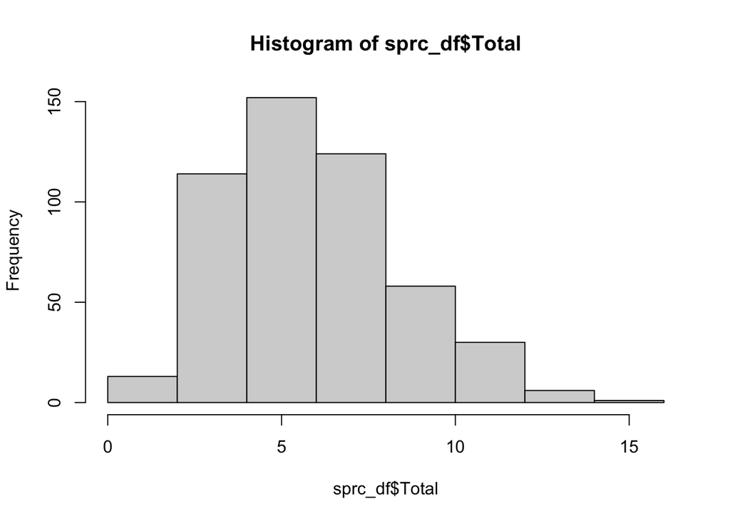

```r
sprc_df <- veg_merge2 %>%
  mutate_if(is.numeric, ~1 * (. > 0))

sprc_df$Total<- rowSums(sprc_df[2:166])

sprc_df <- sprc_df %>%
  select(Total, everything())

hist(sprc_df$Total) # bit of a tail to the right
```

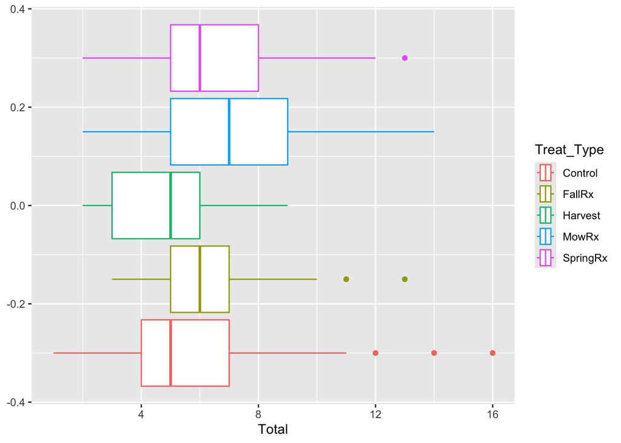

```r
ggplot(data = sprc_df, aes(x = Total, color = Treat_Type))+
  geom_boxplot()
```

```r
# Looking at ANOVA & assumptions
shapiro.test(sprc_df$Total[sprc_df$Treat_Type == "Control"])
```

```
##
##  Shapiro-Wilk normality test
##
## data:  sprc_df$Total[sprc_df$Treat_Type == "Control"]
## W = 0.92627, p-value = 7.259e-06
```

```r
shapiro.test(sprc_df$Total[sprc_df$Treat_Type == "FallRx"])
```

```
##
##  Shapiro-Wilk normality test
##
## data:  sprc_df$Total[sprc_df$Treat_Type == "FallRx"]
## W = 0.95067, p-value = 0.0008008
```

```r
shapiro.test(sprc_df$Total[sprc_df$Treat_Type == "SpringRx"])
```

```
##
##  Shapiro-Wilk normality test
##
## data:  sprc_df$Total[sprc_df$Treat_Type == "SpringRx"]
## W = 0.96508, p-value = 0.01894
```

```r
shapiro.test(sprc_df$Total[sprc_df$Treat_Type == "Harvest"])
```

```
##
##  Shapiro-Wilk normality test
##
## data:  sprc_df$Total[sprc_df$Treat_Type == "Harvest"]
## W = 0.94196, p-value = 0.009431
```

```r
shapiro.test(sprc_df$Total[sprc_df$Treat_Type == "MowRx"])
```

```
##
##  Shapiro-Wilk normality test
##
## data:  sprc_df$Total[sprc_df$Treat_Type == "MowRx"]
## W = 0.96974, p-value = 0.004025
```

```r
# none pass - will have to check residuals?

car::leveneTest(Total~Treat_Type, data = sprc_df)
```

```
## Levene's Test for Homogeneity of Variance (center = median)
##        Df F value    Pr(>F)
## group   4   4.786 0.0008528 ***
##       493
## ---
## Signif. codes:  0 '***' 0.001 '**' 0.01 '*' 0.05 '.' 0.1 ' ' 1
```

```r
#also doesn't pass

x <- aov(Total ~ Treat_Type, data = sprc_df)

summary(x)
```

```
##              Df Sum Sq Mean Sq F value   Pr(>F)
## Treat_Type    4  277.6   69.40   11.98 2.68e-09 ***
## Residuals   493 2855.7    5.79
## ---
## Signif. codes:  0 '***' 0.001 '**' 0.01 '*' 0.05 '.' 0.1 ' ' 1
```

```r
TukeyHSD(x)
```

```
##   Tukey multiple comparisons of means
##     95% family-wise confidence level
##
## Fit: aov(formula = Total ~ Treat_Type, data = sprc_df)
##
## $Treat_Type
##                        diff        lwr        upr     p adj
## FallRx-Control    0.4881850 -0.4044670  1.3808371 0.5646928
## Harvest-Control  -0.8220391 -1.8927920  0.2487139 0.2208211
## MowRx-Control     1.5445576  0.7136532  2.3754619 0.0000051
## SpringRx-Control  0.6964338 -0.2364245  1.6292922 0.2466370
## Harvest-FallRx   -1.3102241 -2.4061662 -0.2142820 0.0099809
## MowRx-FallRx      1.0563725  0.1932507  1.9194944 0.0077003
## SpringRx-FallRx   0.2082488 -0.7534174  1.1699150 0.9761227
## MowRx-Harvest     2.3665966  1.3203350  3.4128583 0.0000000
## SpringRx-Harvest  1.5184729  0.3895415  2.6474043 0.0023728
## SpringRx-MowRx   -0.8481237 -1.7527653  0.0565178 0.0781894
```

### Using non-parametric methods

```r
library(dunn.test)
kruskal.test(Total~Treat_Type, data = sprc_df)
```

```
##
##  Kruskal-Wallis rank sum test
##
## data:  Total by Treat_Type
## Kruskal-Wallis chi-squared = 43.798, df = 4, p-value = 7.068e-09
```

```r
dunn.test(x = sprc_df$Total, g = sprc_df$Treat_Type, method = "bonferroni")
```

```
##   Kruskal-Wallis rank sum test
##
## data: x and group
## Kruskal-Wallis chi-squared = 43.7976, df = 4, p-value = 0
##
##
##                            Comparison of x by group
##                                  (Bonferroni)
## Col Mean-|
## Row Mean |    Control     FallRx    Harvest      MowRx
## ---------+--------------------------------------------
##   FallRx |  -2.033737
##          |     0.2099
##  Harvest |   1.836270   3.450557
##          |     0.3316    0.0028*
##    MowRx |  -4.937739  -2.650111  -5.800633
##          |    0.0000*     0.0402    0.0000*
## SpringRx |  -2.398364  -0.438732  -3.723455   2.062093
##          |     0.0823     1.0000    0.0010*     0.1960
##
## alpha = 0.05
## Reject Ho if p <= alpha/2
```

##### Species Richness

```r
# Species Richness (jackknife and chao etc estimates) -------------------
sp1 <- as.data.frame(sapply(split_TT, species_richness))

#transpose
spcrich_byTT <- as.data.frame(t(sp1))

rm(sp1)
```

##### Diversity (Shannon-Wiener Index)

```r
# Shannon index -------------------
si1 <- as.data.frame(sapply(split_TT, shannon_index))

#transpose
si_byTT <- as.data.frame(t(si1))

#name columns
colnames(si_byTT) <- c("S.I._Mean", "S.I._SD")

rm(si1)
```

##### Species Number

```r
# Number of species -------------------
spc_n1 <- as.data.frame(sapply(split_TT, spec_num))

#transpose
spcnum_byTT <- as.data.frame(t(spc_n1))

#name columns
colnames(spcnum_byTT) <- c("Spc.Num_Mean", "Spc.Num_SD")

rm(spc_n1)


# #at a later date fix and take a look at aov for this
# spTT2 <- tibble::rownames_to_column(spcnum_byTT, "rn")
#
# spnum_avo <- aov(Spc.Num_Mean ~ rn, data = spTT2)
# print(spnum_avo)
#
# mat1 <- matrix(nrow = 5, ncol = 136)
#
# mat1[1,] <- specnumber(split_TT$Control)
# z1 <- specnumber(split_TT$Harvest)
# z2 <- specnumber(split_TT$SpringRx)
# z3 <- specnumber(split_TT$FallRx)
# z4 <- specnumber(split_TT$MowRx)
#
# x <- bind_rows(z, z1)
# x1 <- bind_rows(x, z2)
# x2 <- bind_rows(x1, z3)
# speTT <- bind_rows(x2, z4)
```

##### Evenness (Pielou’s J)

This is the SW Index / log (species number). For three sites (one each in APB_Hippo, RPD2_B2, & RPD2_B7), they have a species number of 1. The log of 1 is 0 and anything divided by 0 is NaN. Therefore, these three subplots are dropped from the calculations

```r
even1a <- as.data.frame(sapply(split_TT, Pielous_J))

even2a <- as.data.frame(t(even1a))

colnames(even2a) <- c("Pielous_J_mean", "Pielous_J_SD")

rm(even1a)
```

Hidden below is code to look at the three subplots, if desired

### Sorensen dissimilarity index

```r
# creating a dataframe where observations from every subplot within a site are added together to use for P/A calculations in sorensen
veg4soren2 <- veg_merge2 %>%
  group_by(Treat_Type) %>%
  summarise_at(vars(QUCO:HECA), sum) %>%
  column_to_rownames(var = "Treat_Type")

# creating df of row id and site id to reattach to beta diversity metrics later
site_rowid2 <- veg_merge2 %>%
  group_by(Treat_Type) %>%
  summarise_at(vars(QUCO:HECA), sum) %>%
  rowid_to_column(var="rowid") %>%
  select(Treat_Type, rowid)
```

### Merge DS together

```r
# merging data sets of DS
m1a <- merge(spcrich_byTT, si_byTT, by="row.names") %>%
  column_to_rownames(var = "Row.names")


m2a <- merge(m1a, spcnum_byTT, by="row.names") %>%
  column_to_rownames(var = "Row.names")

m3a <- merge(m2a, even2a, by = "row.names") %>%
  column_to_rownames(var = "Row.names")

try2 <- m3a

# m4a <- merge(m3a, rich.df2, by = "row.names") %>%
#   column_to_rownames(var = "Row.names")
#
# veg_sd <- merge(m4, rep.df2, by = "row.names") %>%
#   column_to_rownames(var = "Row.names")


rm(m1a,
   m2a)
   # m3,
   # m4)

write_csv(try2, "DataObjects/DSbyTreatType.csv")
```